# Factor Analysis - Personality

Sabyasachi Sahu (sab21.sahu@gmail.com)

3 February 2017

# INTRODUCTION

Factor Analysis is a method (not unlike SEM) for analyzing the covariation among the observed variables to address the questions:

*How many latent factors are needed to account for most of the variation among the observed variables?* Which variables appear to define each factor; hence what labels should we give to these factors? If the observed covariation can be explained by a small number of factors (e.g., 2-5), this would increase our understanding of the relationships among the traits or variables!

```r
##Loading Data
d = read.table("http://www.stanford.edu/class/psych253/data/personality0.txt")
head(d)
```

```
##   distant talkatv carelss hardwrk anxious agreebl tense kind opposng
## 1       2       7       1       4       7       8     5    9       5
## 2       3       8       2       7       5       8     4    8       5
## 3       6       6       2       5       1       8     2    9       2
## 4       3       7       6       7       8       8     2    8       3
## 5       7       3       3       5       8       6     7    2       3
## 6       7       6       7       6       7       8     7    8       5
##   relaxed disorgn outgoin approvn shy discipl harsh persevr friendl
## 1       6       3       2       7   9       5     5       8       9
## 2       7       5       8       7   6       7     3       7       7
## 3       8       7       6       7   5       5     2       5       8
## 4       7       2       5       6   4       6     2       8       8
## 5       3       5       2       5   8       7     5       6       2
## 6       5       6       5       6   8       5     3       6       7
##   worryin respnsi contrar sociabl lazy coopera quiet organiz criticl lax
## 1       9       9       5       9    7       9     9       5       5   5
## 2       5       7       5       8    2       7     6       6       4   3
## 3       3       9       2       8    5       8     7       4       5   5
## 4       3       8       2       6    3       8     4       7       6   6
## 5       8       7       3       2    6       6     7       5       5   3
## 6       7       7       5       4    5       7     8       6       6   4
##   laidbck withdrw givinup easygon
## 1       7       5       5       8
## 2       7       2       2       7
## 3       7       6       2       8
## 4       6       4       3       7
## 5       3       7       5       5
## 6       4       6       4       7
```

```r
names(d)
```

```
##  [1] "distant" "talkatv" "carelss" "hardwrk" "anxious" "agreebl" "tense"
##  [8] "kind"    "opposng" "relaxed" "disorgn" "outgoin" "approvn" "shy"
## [15] "discipl" "harsh"   "persevr" "friendl" "worryin" "respnsi" "contrar"
## [22] "sociabl" "lazy"    "coopera" "quiet"   "organiz" "criticl" "lax"
## [29] "laidbck" "withdrw" "givinup" "easygon"
```

## Using Coorplot

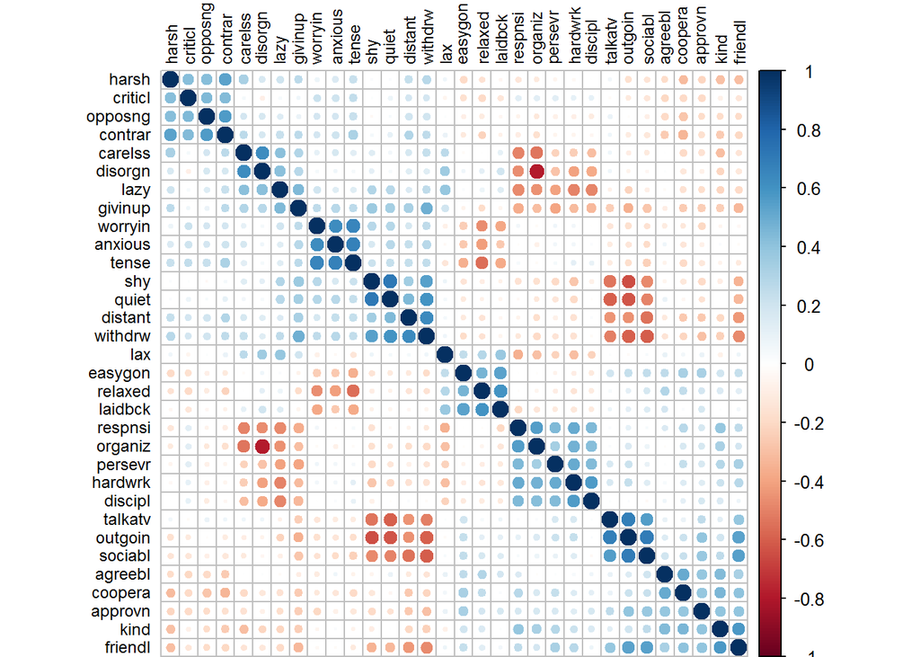

```r
#install.packages("corrplot")
library(corrplot)
#?corrplot
corrplot(cor(d), order = "hclust", tl.col='black', tl.cex=.75)
```

## Factor Analysis with R

Factor Analysis with No rotation

```r
d_stan = as.data.frame(scale(d))
### Factor analysis with no rotation
res1b = factanal(d_stan, factors = 10, rotation = "none", na.action = na.omit)
res1b$loadings
```

```
##
## Loadings:
##         Factor1 Factor2 Factor3 Factor4 Factor5 Factor6 Factor7 Factor8
## distant  0.593   0.269                           0.207  -0.101
## talkatv -0.505  -0.513           0.270  -0.114
## carelss  0.460  -0.474   0.106   0.141   0.167   0.125  -0.115
## hardwrk -0.457   0.326  -0.136   0.348  -0.166          -0.315
## anxious  0.289          -0.277   0.599   0.231  -0.252          -0.104
## agreebl -0.325           0.201           0.818   0.192          -0.136
## tense    0.319          -0.391   0.628          -0.244          -0.142
## kind    -0.488   0.222                   0.376                   0.327
## opposng  0.290  -0.168           0.404  -0.217   0.330   0.189   0.194
## relaxed -0.177           0.602  -0.311   0.155   0.187           0.176
## disorgn  0.462  -0.640   0.199           0.251          -0.302
## outgoin -0.690  -0.435   0.128   0.233  -0.104
## approvn -0.468           0.187           0.267                   0.106
## shy      0.612   0.345          -0.155   0.242  -0.187           0.150
## discipl -0.303   0.451  -0.127   0.214  -0.100   0.185  -0.329
## harsh    0.376  -0.125           0.354  -0.218   0.446   0.158
## persevr -0.398   0.250  -0.115   0.277  -0.106          -0.371   0.187
## friendl -0.642  -0.141           0.184   0.220  -0.193           0.313
## worryin  0.296          -0.401   0.484   0.123  -0.376
## respnsi -0.463   0.478  -0.209   0.172           0.146  -0.140   0.172
## contrar  0.389  -0.154           0.437  -0.231   0.312   0.166   0.172
## sociabl -0.619  -0.408   0.158   0.107          -0.119   0.158
## lazy     0.529  -0.318   0.135           0.195  -0.141   0.323   0.122
## coopera -0.464   0.105                   0.459                   0.196
## quiet    0.574   0.461                   0.346                   0.187
## organiz -0.522   0.588  -0.147   0.106  -0.261           0.211
## criticl  0.186   0.112  -0.142   0.400  -0.257   0.276   0.154   0.185
## lax      0.210  -0.242   0.383           0.165           0.104   0.166
## laidbck                  0.997
## withdrw  0.726   0.344                           0.138
## givinup  0.600                           0.135           0.242
## easygon -0.220           0.542           0.143           0.104   0.208
##         Factor9 Factor10
## distant -0.221   0.214
## talkatv
## carelss  0.183
## hardwrk  0.170
```

[output cut: 22 more lines]

```
## criticl         -0.147
## lax      0.124
## laidbck
## withdrw          0.306
## givinup  0.101   0.255
## easygon -0.105   0.117
##
##                Factor1 Factor2 Factor3 Factor4 Factor5 Factor6 Factor7
## SS loadings      6.706   3.071   2.554   2.283   1.979   1.105   0.867
## Proportion Var   0.210   0.096   0.080   0.071   0.062   0.035   0.027
## Cumulative Var   0.210   0.306   0.385   0.457   0.519   0.553   0.580
##                Factor8 Factor9 Factor10
## SS loadings      0.689   0.393    0.382
## Proportion Var   0.022   0.012    0.012
## Cumulative Var   0.602   0.614    0.626
```

## Compute eigenvalues from factor loadings

```r
# Compute eigenvalue of factor 1
loadings_fac1 = res1b$loadings[,1]
eigenv_fac1 = sum(loadings_fac1^2); eigenv_fac1
```

```
## [1] 6.706499
```

```r
# Compute proportion variance manually
eigenv_fac1/32
```

```
## [1] 0.2095781
```

## Uniqueness & Communality

We can also look at the uniqueness of each variable. Uniqueness =1 - Communality, where Communality is SS factor loadings for all factors for a given variable. If all the factors jointly explain a large percent of variance in a given variable, that variable has high Communality (and thus low uniqueness). Let’s look at the **uniqueness of the variables, and then try to calculate uniqueness for the variable distant by ourselves!

```r
res1b$uniquenesses
```

```
##   distant   talkatv   carelss   hardwrk   anxious   agreebl     tense
## 0.4155265 0.3662366 0.4332678 0.3765560 0.3414400 0.1085821 0.2479509
##      kind   opposng   relaxed   disorgn   outgoin   approvn       shy
## 0.4473867 0.4135546 0.4137453 0.1676505 0.2036158 0.6424638 0.3227601
##   discipl     harsh   persevr   friendl   worryin   respnsi   contrar
## 0.4613517 0.3813236 0.4950613 0.3363327 0.3481255 0.3921460 0.4166332
##   sociabl      lazy   coopera     quiet   organiz   criticl       lax
## 0.3574583 0.4100754 0.5047471 0.2855130 0.2315167 0.5504645 0.6611637
##   laidbck   withdrw   givinup   easygon
## 0.0050000 0.2170508 0.4644383 0.5503472
```

```r
# Calculate uniqueness
loadings_distant = res1b$loadings[1,]
communality_distant = sum(loadings_distant^2); communality_distant
```

```
## [1] 0.5844747
```

```r
uniqueness_distant = 1-communality_distant; uniqueness_distant
```

```
## [1] 0.4155253
```

## Visualize Loadings

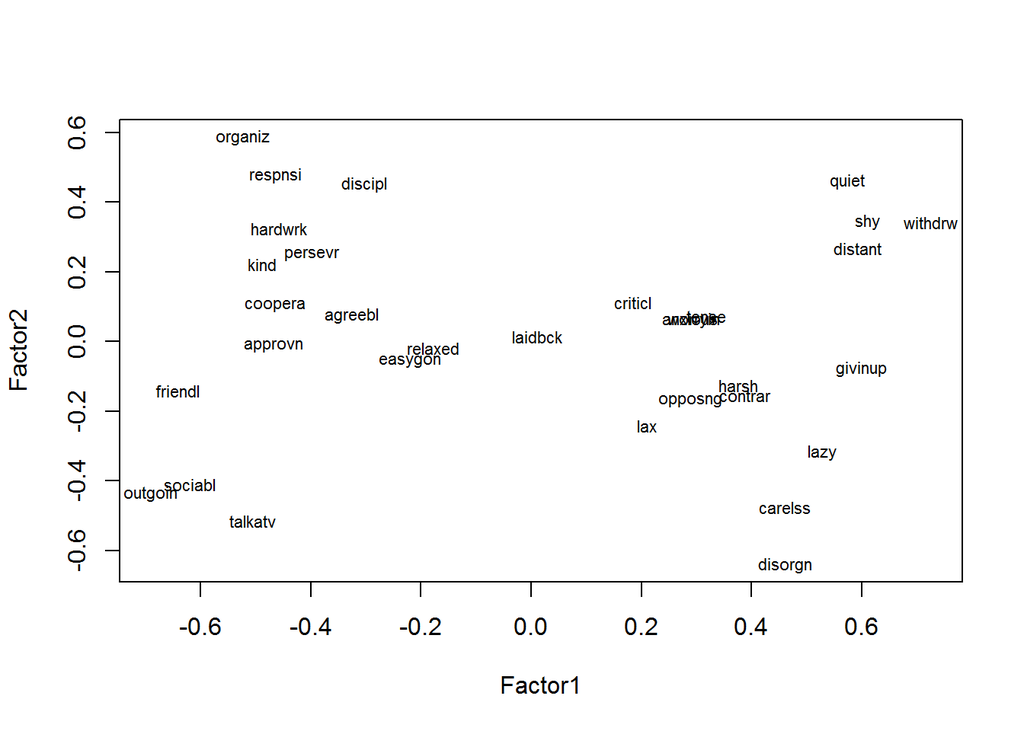

```r
### Plot loadings against one another
load = res1b$loadings[,1:2]
plot(load, type="n") # set up plot
text(load,labels=names(d_stan),cex=.7) # add variable names
```

It can be difficult to label factors when they are unrotated, since a description of one factor might overlap with a description of another factor. For instance, we we could define Factor 1 as talkative & organized vs. quiet & disorganized, but Factor 2 could be defined as talkative & disorganized vs. organized and quiet - this doesn’t make much sense! However, let’s see what happens when we rotate the factors. Note that when the “best-fitting” factors are found, these factors are not unique. Any rotation of the best-fittng factors is also best-fitting.

## Rotation of Factors

There are many methods we can use to rotate the factors, but the method called varimax rotation is the most common, and thus the default in R’s factanal(). Varimax rotation essentially orthogonally rotates the factor axes with the goal of maximizing the variance of the squared loadings of a factor on all the variables in the factor matrix. In other words, varimax rotation looks for a rotation (i.e., a linear combination) of the original factors that maximizes the variance of the loadings. As a result, each variable tends to load more heavily on a single factor (and load very little on other factors), making the interpretation of a factor easier.

```r
### Factor analysis with rotation
res1a = factanal(d_stan, factors = 10, rotation = "varimax", na.action = na.omit)
res1a$loadings
```

```
##
## Loadings:
##         Factor1 Factor2 Factor3 Factor4 Factor5 Factor6 Factor7 Factor8
## distant  0.571           0.120  -0.149   0.120   0.231
## talkatv -0.762                   0.109   0.109   0.128
## carelss         -0.242   0.104  -0.102   0.630   0.180
## hardwrk -0.185   0.716   0.125          -0.199
## anxious  0.138           0.773                   0.135
## agreebl                          0.736          -0.162   0.136  -0.545
## tense    0.136           0.805                   0.206  -0.152
## kind             0.201           0.655  -0.185  -0.122           0.100
## opposng         -0.101   0.119  -0.114           0.704
## relaxed         -0.113  -0.535   0.270                   0.441
## disorgn         -0.301                   0.848
## outgoin -0.844                   0.191
## approvn -0.283   0.126           0.450          -0.149   0.167
## shy      0.742  -0.196   0.158                                   0.121
## discipl          0.693                  -0.184
## harsh                           -0.237   0.162   0.651          -0.149
## persevr -0.128   0.638           0.185                           0.183
## friendl -0.488   0.162           0.550          -0.153           0.226
## worryin  0.164           0.748                   0.110  -0.169   0.149
## respnsi          0.555           0.317  -0.380          -0.116
## contrar                  0.165  -0.167   0.136   0.702
## sociabl -0.722                   0.267
## lazy     0.170  -0.625   0.140           0.267   0.157   0.115
## coopera          0.129  -0.136   0.625          -0.242
## quiet    0.790  -0.138   0.201   0.158
## organiz          0.405           0.105  -0.759
## criticl          0.119   0.138          -0.113   0.619
## lax             -0.327           0.110   0.273           0.322
## laidbck                 -0.281           0.117           0.941
## withdrw  0.724           0.153  -0.124   0.119   0.209
## givinup  0.329  -0.436   0.255  -0.133   0.146   0.109
## easygon -0.159  -0.134  -0.256   0.302                   0.479
##         Factor9 Factor10
## distant          0.390
## talkatv
## carelss  0.221
## hardwrk  0.119
```

[output cut: 22 more lines]

```
## criticl
## lax      0.153
## laidbck
## withdrw  0.225   0.325
## givinup  0.319   0.140
## easygon          0.104
##
##                Factor1 Factor2 Factor3 Factor4 Factor5 Factor6 Factor7
## SS loadings      4.476   2.954   2.559   2.522   2.268   2.230   1.591
## Proportion Var   0.140   0.092   0.080   0.079   0.071   0.070   0.050
## Cumulative Var   0.140   0.232   0.312   0.391   0.462   0.532   0.581
##                Factor8 Factor9 Factor10
## SS loadings      0.531   0.485    0.415
## Proportion Var   0.017   0.015    0.013
## Cumulative Var   0.598   0.613    0.626
```

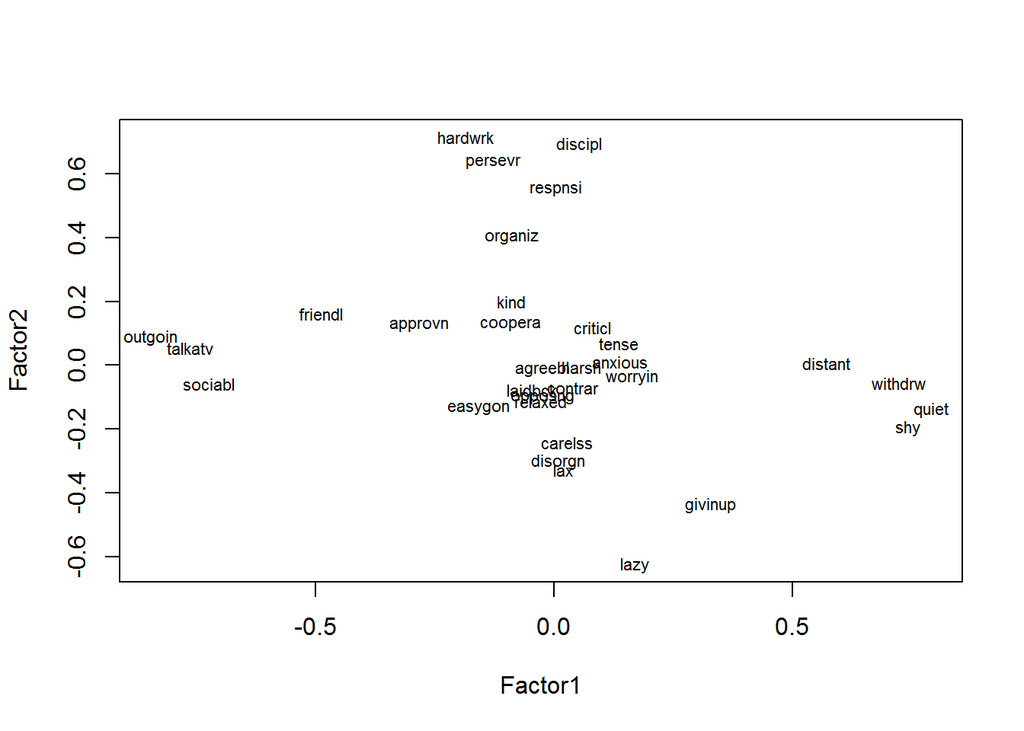

```r
### Plot loadings against one another
load = res1a$loadings[,1:2]
plot(load, type="n") # set up plot
text(load,labels=names(d_stan),cex=.7) # add variable names
```

Here we can see that now variables like sociabl and shy load heavily on Factor 1, but have very low loadings on Factor 2. As a result, we can define or label Factor 1 using these terms (e.g., extraverted vs. introverted), and then define Factor 2 using terms that load heavily on Factor 2 but less so on Factor 1 (e.g., Factor 2 might be conscientiousness, i.e., hardwrk vs. lazy).

## Creating composite variables

```r
shy = rowMeans(cbind(d_stan$distant, d_stan$shy, d_stan$withdrw, d_stan$quiet))
outgoing = rowMeans(cbind(d_stan$talkatv, d_stan$outgoin, d_stan$sociabl))
hardworking = rowMeans(cbind(d_stan$hardwrk, d_stan$persevr, d_stan$discipl))
friendly = rowMeans(cbind(d_stan$friendl, d_stan$kind, d_stan$coopera, d_stan$agreebl, d_stan$approvn,
    d_stan$sociabl))
anxious = rowMeans(cbind(d_stan$tense, d_stan$anxious, d_stan$worryin))
#etc, you guys choose what you want to combine
combined_data = cbind(shy,outgoing,hardworking,friendly,anxious)
combined_data = as.data.frame(combined_data)
res2 = factanal(combined_data, factors = 2, na.action=na.omit)
res2$loadings
```

```
##
## Loadings:
##             Factor1 Factor2
## shy          0.968  -0.241
## outgoing    -0.683   0.432
## hardworking -0.126   0.233
## friendly    -0.214   0.974
## anxious      0.321
##
##                Factor1 Factor2
## SS loadings      1.568   1.258
## Proportion Var   0.314   0.252
## Cumulative Var   0.314   0.565
```

# Plotting

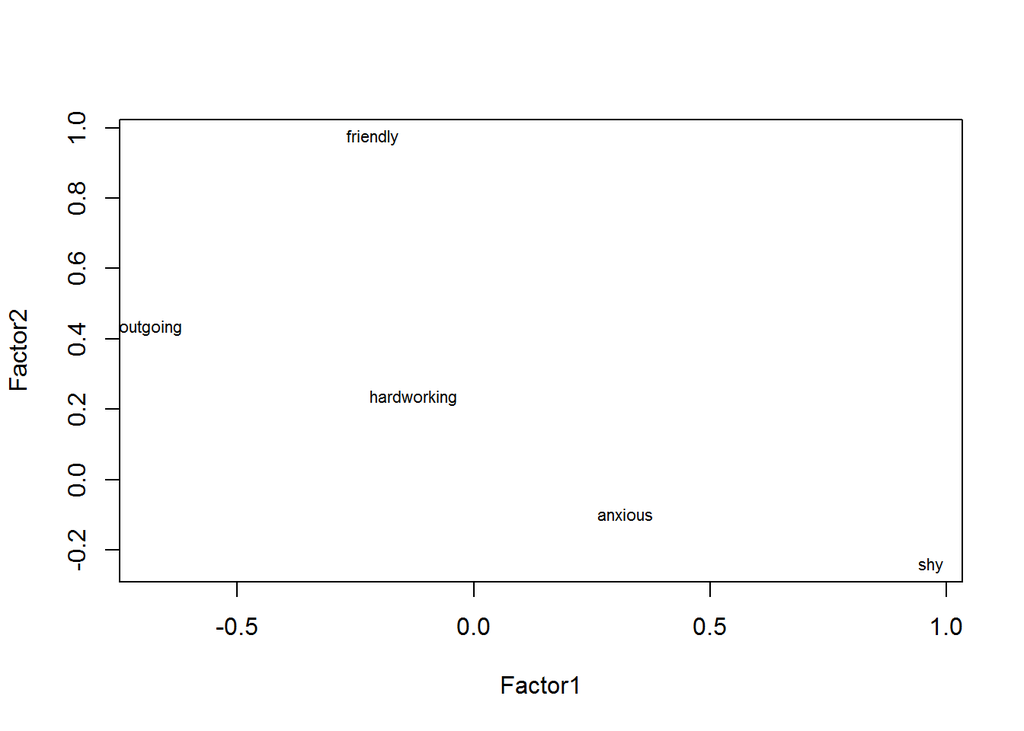

```r
### Plot loadings against one another
load = res2$loadings[,1:2]
plot(load, type="n") # set up plot
text(load,labels=names(combined_data),cex=.7) # add variable names
```

## Conclusion

On a related note, redundant or synonymous variables hinder the extraction of general factors. Synonomous variables can be combined into composites.